# 3.1. Functions and Libraries

Module M-227-04: Programming for Data Analytics

Instructor: prof. Dmitry Pavlyuk

## Functions

If you anticipate needing to repeat the same or very similar code more than once, it may be worth writing a reusable function.

```python
def plusone(x):
    "This is a short explanation on your function: this function adds 1 to the passed argument"
    print(f"Calling the 'plusone' function with argument '{x}'")
    return x+1
```

```python
print(plusone(11))
```

```
Calling the 'plusone' function with argument '11'
12
```

```python
help(plusone)
```

```
Help on function plusone in module __main__:

plusone(x)
    This is a short explanation on your function: this function adds 1 to the passed argument
```

### Function of two arguments

```python
def my_power(base, exponent):
    "Return the 'base' to the power of 'exponent'"
    return base**exponent
```

```python
my_power(2,3)
```

```
8
```

### Function arguments

- Positional vs. Keyword arguments

```python
def my_power(base, exponent):
    "Return the 'base' to the power of 'exponent'"
    return(base**exponent)

print(my_power(2,3))
print(my_power(3,2))
```

```
8
9
```

```python
def my_power(base, exponent=1):
    "Return the 'base' to the power of 'exponent'"
    return(base**exponent)

print(my_power(2,3))
print(my_power(3,2))
print(my_power(base=3,exponent=2))
print(my_power(exponent=2,base=3))
```

```
8
9
9
9
```

### Function arguments

- Multiple positional arguments

```python
def helloAll1(*names):
    for name in names:
        print(f"Hello, {name}!")

helloAll1("John", "Jim")
```

```
Hello, John!
Hello, Jim!
```

- Multiple keyword arguments

```python
def helloAll2(**namesDict):
    for name in namesDict:
        print(f"Hello, {name} {namesDict[name]}!")


helloAll2(Mr = "John", Dr = "Jim")
```

```
Hello, Mr John!
Hello, Dr Jim!
```

- All types of arguments

```python
def helloAll3(first, *names, **namesDict):
    print(f"Hello, {first}!!!!!")
    for name in names:
        print(f"Hello, {name}!")
    for name in namesDict:
        print(f"Hello, {name} {namesDict[name]}!")


helloAll3("Janis", "Jane", "Jack", Mr = "John", Dr = "Jim")
```

```
Hello, Janis!!!!!
Hello, Jane!
Hello, Jack!
Hello, Mr John!
Hello, Dr Jim!
```

### Function returns

- Single value

```python
def addition(a, b):
    return a+b

addition(2,3)
```

```
5
```

- Tuple

```python
def add_multiply1(a, b):
    return a+b, a*b

add_multiply1(2,3)
```

```
(5, 6)
```

- Dictionary

```python
def add_multiply2(a, b):
    return{"sum":a+b, "product":a*b}

add_multiply2(2,3)
```

```
{'sum': 5, 'product': 6}
```

### Testing functions: Asserts

```python
assert plusone(1)==2, "Ok"
assert add_multiply2(2,3)['product'] == 6, "Ok"
```

```
Calling the 'plusone' function with argument '1'
```

```python
assert plusone(2)==2, "Ok"
```

```
Calling the 'plusone' function with argument '2'
```

```
---------------------------------------------------------------------------
AssertionError                            Traceback (most recent call last)
Input In [15], in <cell line: 1>()
----> 1 assert plusone(2)==2, "Ok"

AssertionError: Ok
```

## Functions are objects

Functions are the objects, so you can pass them as arguments

```python
students = ('aLexey!', '    anar', '..erika', ' Jevgenijs!!! ', '##janis', 'vjaceSLAV', 'NIKITa')

import re
def remove_punctuation(value):
    return re.sub("[!#?.]", "", value)


def run_all_funcs(strings, funcs):
    result = []
    for value in strings:
        for func in funcs:
            value = func(value)
        result.append(value)
    return result

clean_funcs = [str.strip, remove_punctuation, str.capitalize]
students_cleaned = run_all_funcs(students,clean_funcs)
print(students_cleaned)
```

```
['Alexey', 'Anar', 'Erika', 'Jevgenijs', 'Janis', 'Vjaceslav', 'Nikita']
```

## Namespaces

A namespace is a 'place' with a set of names and their corresponding objects.

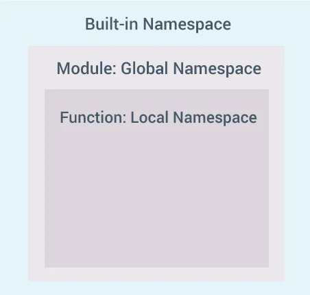

## Namespaces

- The built-in namespace contains the names of all of Python’s built-in objects. These are available at all times when Python is running.
- The global namespace contains any names defined at the level of the main program. Python creates the global namespace when the main program body starts, and it remains in existence until the interpreter terminates.
- Python creates a new namespace whenever a function executes. That namespace is local to the function and remains in existence until the function terminates.

```python
val = "My Value"
def func():
    val = "My Local Value"
    print("Local value: " + val)

func()
print(val)
```

```
Local value: My Local Value
My Value
```

### Globals and Locals dictionaries

- globals() returns an actual reference to the dictionary that contains the global namespace
- locals() returns a dictionary that is a current copy of the local namespace, not a reference to it.

```python
val = "My Value"
def func():
    val = "My Local Value"
    local_vars = locals()
    print("Local value: " + local_vars["val"])
    global_vars = globals()
    print("Global value: " + global_vars["val"])

func()
print(val)
```

```
Local value: My Local Value
Global value: My Value
My Value
```

```python
val = "My Value"
def func():
    global val
    val = "My Local Value"

func()
print(val)
```

```
My Local Value
```

I recommend NOT to use *global* variables in functions while it is not absolutely necessary!

## Lambda functions

Python supports *anonymous* or *lambda* functions, which are a way of writing functions consisting of a single statement, the result of which is the return value.

It's often clearer to pass a lambda function as an argument as opposed to writing a complete function declaration:

```python
funcs = [lambda s: s+"! ",
        lambda s: s*3,]
run_all_funcs(students_cleaned,funcs)
```

```
['Alexey! Alexey! Alexey! ',
 'Anar! Anar! Anar! ',
 'Erika! Erika! Erika! ',
 'Jevgenijs! Jevgenijs! Jevgenijs! ',
 'Janis! Janis! Janis! ',
 'Vjaceslav! Vjaceslav! Vjaceslav! ',
 'Nikita! Nikita! Nikita! ']
```

## Libraries

A **library** is an umbrella term referring to a reusable chunk of code. It is often assumed that while a **package** is a collection of **modules**, a **library** is a collection of **packages**.

So

- The **module** is a simple Python file that contains collections of functions and variables and with having a .py extension file.
- The **package** is a simple directory having collections of modules.
- The **library** is having a collection of packages.

## Standard libraries

- Standard (built-in) libraries are usually installed with Python
- A long list of built-in libraries https://docs.python.org/3/py-modindex.html
- Most frequently used - **math**, **random**, **statistics**, **datetime**, **json**, etc.
- Need to be imported before usage

## Importing

- Importing all content (functions, variables, etc.)

```python
import math
print(f"Pi is {math.pi}")
print(f"Square root of 2 is {math.sqrt(2)}")
```

```
Pi is 3.141592653589793
Square root of 2 is 1.4142135623730951
```

- Importing all content by alias

```python
import math as my_lovely_math
print(f"Pi is {my_lovely_math.pi}")
print(f"Square root of 2 is {my_lovely_math.sqrt(2)}")
```

```
Pi is 3.141592653589793
Square root of 2 is 1.4142135623730951
```

- Importing selected variables, functions

```python
from math import pi, sqrt
print(f"Pi is {pi}")
print(f"Square root of 2 is {sqrt(2)}")
```

```
Pi is 3.141592653589793
Square root of 2 is 1.4142135623730951
```

- Importing all functions (not recommended)

```python
from math import *
print(f"Pi is {pi}")
print(f"Square root of 2 is {sqrt(2)}")
```

```
Pi is 3.141592653589793
Square root of 2 is 1.4142135623730951
```

- Check library content

```python
dir(math)
print(", ".join(dir(math)))
```

```
__doc__, __loader__, __name__, __package__, __spec__, acos, acosh, asin, asinh, atan, atan2, atanh, ceil, comb, copysign, cos, cosh, degrees, dist, e, erf, erfc, exp, expm1, fabs, factorial, floor, fmod, frexp, fsum, gamma, gcd, hypot, inf, isclose, isfinite, isinf, isnan, isqrt, lcm, ldexp, lgamma,…
```

## Examples

```python
import random
print(random.randint(0,100))
```

```
75
```

```python
import statistics
vals = [10, 30, 50, 70, 90]
print(statistics.mean(vals))
print(statistics.median(vals))
print(statistics.mode(vals))
print(statistics.stdev(vals))
```

```
50
50
10
31.622776601683793
```

## Third-party libraries

## Installing

- **pip** installs *python* packages in *any* environment
- **conda** installs *any* package in *conda* environments
- **pip** from shell

pip install numpy

- **pip** from Jupyter notebook

```python
!pip install numpy
```

## Your own modules

Constructing you own module is simple - just creare the python script file (.py) with all your functions and use it as a built-in library:

```python
import mylib

mylib.myprint("Dmitry")
```

```
D
m
i
t
r
y
```

### Module: search paths

```python
import sys
sys.path
```

```
['E:\\Dmitry\\Dropbox\\open\\courses\\M_Programming_for_DataAnalytics\\python-da\\week3',
 'C:\\Users\\dmitry\\anaconda3\\python39.zip',
 'C:\\Users\\dmitry\\anaconda3\\DLLs',
 'C:\\Users\\dmitry\\anaconda3\\lib',
 'C:\\Users\\dmitry\\anaconda3',
 '',
 'C:\\Users\\dmitry\\anaconda3\\lib\\site-packages',
 'C:\\Users\\dmitry\\anaconda3\\lib\\site-packages\\win32',
 'C:\\Users\\dmitry\\anaconda3\\lib\\site-packages\\win32\\lib',
 'C:\\Users\\dmitry\\anaconda3\\lib\\site-packages\\Pythonwin']
```

### Module: content

```python
print(dir(mylib))
```

```
['__builtins__', '__cached__', '__doc__', '__file__', '__loader__', '__name__', '__package__', '__spec__', 'myprint']
```

```python
with open('mylib.py') as f:
    print("Content of the mylib library")
    print("---> start of content")
    print(f.read())
    print("<--- end of content")
```

```
Content of the mylib library
---> start of content

def myprint(s):
    for c in s:
        print(c)


if __name__ == "__main__":
    myprint("Test string")
<--- end of content
```

### if **name** == "**main**":

This statement allows distinguishing two cases:

- running the script as a separate programme (**True** in this case)
- loading the script as a library (**False** in this case)